# 06_Class_Activity

Author

Bill Perry

# In class activity 6:

## What did we do last time in activity 5?

- H test for a single population
- 1- and 2-sided tests
- H test for two populations
- **Assumptions of parametric tests**

## Today’s focus:

- MORE R CODE!!!
- Parametric Statistical test assumptions and how to do them
- What to do if they fail?
  - transformations
  - NON PARAMETRIC TESTS - just as good or better

# This code will accompany and reinforce Lecture 6

```r
# Install packages if needed (uncomment if necessary)
# install.packages("readr")
# install.packages("tidyverse")
# install.packages("car")
# install.packages("here")

# Load libraries
library(car)          # For diagnostic tests
library(patchwork)
library(tidyverse)    # For data manipulation and visualization
```

```r
# Load the pine needle data
# Use here() function to specify the path
df <- read_csv("data/lake_trout.csv")
# Examine the first few rows
head(df)
```

```
# A tibble: 6 × 5
  sampling_site species    length_mm mass_g lake
  <chr>         <chr>          <dbl>  <dbl> <chr>
1 I8            lake trout       515   1400 I8
2 I8            lake trout       468   1100 I8
3 I8            lake trout       527   1550 I8
4 I8            lake trout       525   1350 I8
5 I8            lake trout       517   1300 I8
6 I8            lake trout       607   2100 I8
```

# **Part 1:** Exploratory Data Analysis

Before conducting hypothesis tests, we should always explore our data to understand its characteristics.

Let’s calculate summary statistics and create visualizations.

```r
# YOUR TASK: Calculate summary statistics for pine needle length
# Hint: Use summarize() function to calculate mean, sd, n, etc.

# Create a summary table for all pine needles
df_summary <- df %>%
  group_by(lake) %>%
  summarize(
    mean_length = mean(length_mm, na.rm=TRUE),
    sd_length = sd(length_mm, na.rm=TRUE),
    n = sum(!is.na(length_mm)),
    se_length = sd_length / sqrt(n)
  )

print(df_summary)
```

```
# A tibble: 6 × 5
  lake        mean_length sd_length     n se_length
  <chr>             <dbl>     <dbl> <int>     <dbl>
1 I8                 438.      90.3    87      9.69
2 Island Lake        698.     121.     10     38.2
3 N 01               405.      87.7   658      3.42
4 NE 12              348.     127.    323      7.05
5 NE 14              417.     110.    135      9.42
6 Toolik             381.      98.4   241      6.34
```

```r
# Now calculate summary statistics by wind exposure
# YOUR CODE HERE
```

# **Part 1:** Visualizing the Data

Effective data visualization helps us understand:

- The central tendency
- The spread of the data
- Potential outliers
- Shape of distribution

# Your Task

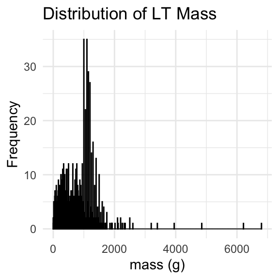

```r
# YOUR TASK: Create a histogram of lke trout mass
# Hint: Use ggplot() and geom_histogram()

# Histogram of all pine needle lengths
ggplot(df, aes(x = mass_g)) +
  geom_histogram(binwidth = 2, fill = "steelblue", color = "black") +
  labs(title = "Distribution of LT Mass",
       x = "mass (g)",
       y = "Frequency") +
  theme_minimal()
```

```r
# how can you do this by wind to see both plots
```

Now to make the various plots we talk about only for lake `NE 12`

## We need to select only that data

```r
# Filter for Lake NE 12
ne12_data <- df %>%
  filter(lake == "NE 12") %>%
  filter(!is.na(mass_g))  # Remove any NA values

head(ne12_data)
```

```
# A tibble: 6 × 5
  sampling_site species    length_mm mass_g lake
  <chr>         <chr>          <dbl>  <dbl> <chr>
1 NE 12         lake trout       206     83 NE 12
2 NE 12         lake trout       191     48 NE 12
3 NE 12         lake trout       228     98 NE 12
4 NE 12         lake trout       208     65 NE 12
5 NE 12         lake trout       228     90 NE 12
6 NE 12         lake trout       215     86 NE 12
```

## Make a new histogram

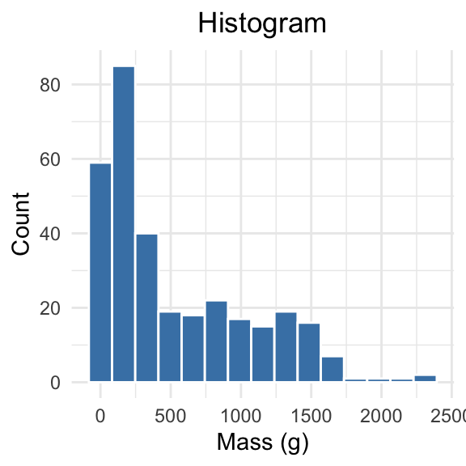

```r
# 1. Histogram
ne12_histo_plot <- ggplot(ne12_data, aes(x = mass_g)) +
  geom_histogram(bins = 15, fill = "steelblue", color = "white") +
  labs(title = "Histogram", x = "Mass (g)", y = "Count") +
  theme_minimal() +
  theme(plot.title = element_text(hjust = 0.5))
ne12_histo_plot
```

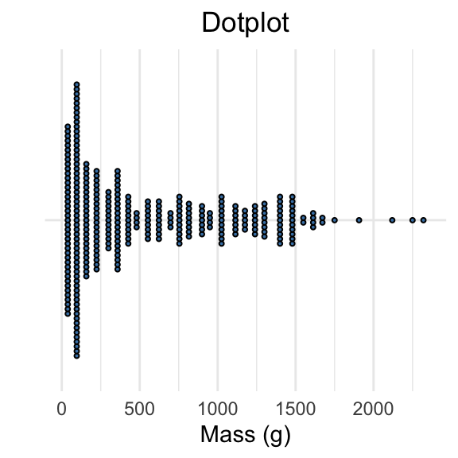

```r
# 2. Dotplot
ne12_dot_plot <- ggplot(ne12_data, aes(x = mass_g, y = "")) +
  geom_dotplot(binwidth = 60, stackdir = "center", fill = "steelblue", dotsize = 0.5) +
  labs(title = "Dotplot", x = "Mass (g)", y = "") +
  theme_minimal() +
  theme(plot.title = element_text(hjust = 0.5),
        axis.text.y = element_blank(),
        axis.ticks.y = element_blank())
ne12_dot_plot
```

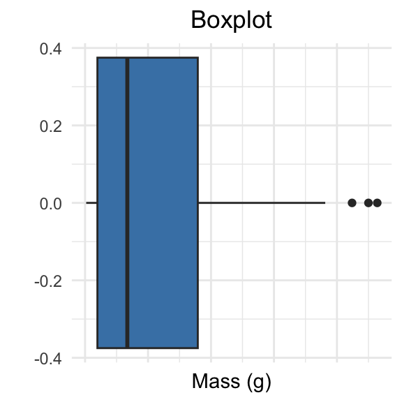

```r
# 3. Boxplot
ne12_box_plot <- ggplot(ne12_data, aes(y = mass_g)) +
  geom_boxplot(fill = "steelblue") +
  labs(title = "Boxplot", y = "Mass (g)", x = "") +
  theme_minimal() +
  theme(plot.title = element_text(hjust = 0.5),
        axis.text.x = element_blank(),
        axis.ticks.x = element_blank()) +
  coord_flip()
ne12_box_plot
```

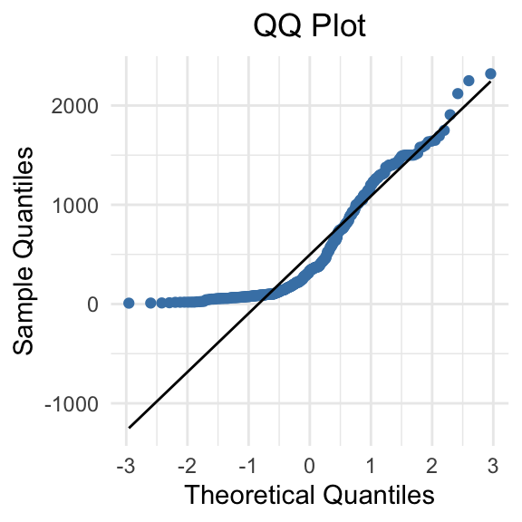

```r
ne12_qq_plot <- ggplot(ne12_data, aes(sample = mass_g)) +
  stat_qq(color = "steelblue") +
  stat_qq_line() +
  labs(title = "QQ Plot", x = "Theoretical Quantiles", y = "Sample Quantiles") +
  theme_minimal() +
  theme(plot.title = element_text(hjust = 0.5))
ne12_qq_plot
```

## Use Patchwork to combine the plots

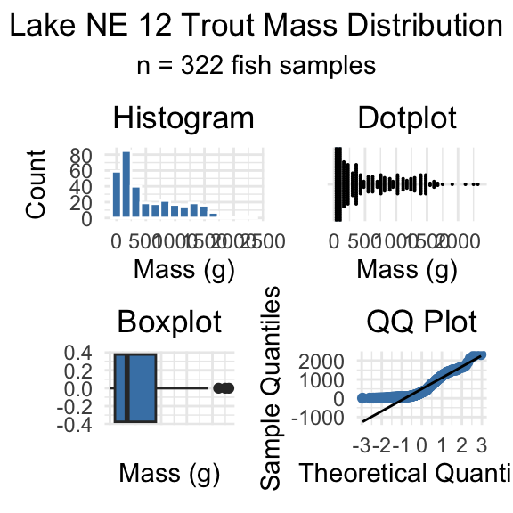

```r
# Combine all plots using patchwork
combined_stats_plot <- (ne12_histo_plot + ne12_dot_plot) / (ne12_box_plot + ne12_qq_plot) +
  plot_annotation(
    title = "Lake NE 12 Trout Mass Distribution",
    subtitle = paste("n =", nrow(ne12_data), "fish samples"),
    theme = theme(plot.title = element_text(hjust = 0.5),
                  plot.subtitle = element_text(hjust = 0.5))
  )

# Display the combined plot
combined_stats_plot
```

# **Part 1:** Single Sample T-Test

We want to test if the mean pine needle length on the windward side differs from 55mm.

**Activity: Define hypotheses and identify assumptions**

H₀: μ = 55 (The mean pine needle length on windward side is 55mm) H₁: μ ≠ 55 (The mean pine needle length on windward side is not 55mm)

## Assumptions for t-test:

1. Data is normally distributed
2. Observations are independent
3. No significant outliers

# **Part 1:** Testing Assumptions

Before conducting our t-test, we need to verify that our data meets the necessary assumptions.

**Activity: Test the normality assumption**

Methods to test normality:

- Visual methods:
  - QQ plots or histograms
  - Statistical tests: Shapiro
  - Wilk test

# Assumptions in R - qqplots

```r
# Filter for just windward side needles
```

## Shapiro Wilk

```r
# Shapiro-Wilk test
# shapiro_test <- shapiro.test(windward_data$len_mm)
# print(shapiro_test)
```

```r
# Check for outliers using boxplot
# YOUR CODE HERE
```

# **Part 1:** Conducting the Single Sample T-Test

Now that we’ve checked our assumptions, we can perform the single sample t-test.

**Activity: Conduct a single sample t-test to compare windward needle length to 55mm** **What is probability of getting sample at least as far from 55mm as our sample mean?**

This is our p-value, which helps us decide whether to reject the null hypothesis.

```r
# Calculate summary statistics for windward needles
# windward_summary <- windward_data %>%
#   summarize(
#     mean_length = mean(len_mm),
#     sd_length = sd(len_mm),
#     n = n(),
#     se_length = sd_length / sqrt(n)
#   )
#
# print(windward_summary)
```

# Your Task

```r
# YOUR TASK: Conduct a single sample t-test
# t_test_result <- t.test(windward_data$len_mm, mu = 55 )
# print(t_test_result)
```

```r
# Calculate t-statistic manually
# YOUR CODE HERE: t = (sample_mean - hypothesized_mean) / (sample_sd / sqrt(n))

# can you do this manually or manually with R?
```

# **Part 1:** Interpreting and Reporting Results

**Activity: Interpret the t-test results**

- What does the p-value tell us?
- Should we reject or fail to reject the null hypothesis?

**How to report this result in a scientific paper:**

“A two-tailed, one-sample t-test at α=0.05 showed that the mean pine needle length on the windward side (… mm, SD = …) [was/was not] significantly different from the expected 55 mm, t(…) = …, p = …”

# **Part 2:** Two Sample T-Test

Now, let’s compare pine needle lengths between windward and leeward sides of trees.

Question: **Is there a significant difference in needle length between the windward and leeward sides?**

This requires a two-sample t-test.

Two-sample t-test compares means from two independent groups.

## $t = \frac{\bar{x}_1 - \bar{x}_2}{S_p\sqrt{\frac{1}{n_1} + \frac{1}{n_2}}}$

where:

- x̄₁ and x̄₂: These represent the sample means of the two groups you’re comparing
- s²ₚ: This is the pooled variance, calculated as: s²ₚ = [(n₁ - 1)s₁² + (n₂ - 1)s₂²] / (n₁ + n₂ - 2), where s₁² and s₂² are the sample variances of the two groups.
- **n₁ and n₂:** These are the sample sizes of the two groups.
- **√(1/n₁ + 1/n₂):** This represents the pooled standard error.

# **Part 2:** Exploratory Data Analysis by Group

**Activity: Calculate summary statistics grouped by wind exposure** Before conducting the test, we need to understand the data for each group.

```r
# YOUR TASK: Calculate summary statistics by wind exposure
# Hint: Use group_by() and summarize()

# group_summary <- pine_data %>%
#   group_by(wind) %>%
#   summarize(
#     mean_length = mean(len_mm),
#     sd_length = sd(len_mm),
#     n = n(),
#     se_length = sd_length / sqrt(n)
#   )
#
# print(group_summary)
```

# Alternative 1

```r
# Calculate the difference in means
# YOUR CODE HERE

# # Assuming your dataframe is called df
# group_summary %>%
#   summarize(difference = mean_length[wind == "wind"] - mean_length[wind == "lee"])
```

# Alternative 2

```r
# # Or alternatively using filter and pull:
# lee_mean <- group_summary %>% filter(wind == "lee") %>% pull(mean_length)
# wind_mean <- group_summary %>% filter(wind == "wind") %>% pull(mean_length)
# difference <- wind_mean - lee_mean
# difference
```

# **Part 2:** Visualizing Group Differences

**Activity: Create visualizations to compare the groups** Effective visualizations for group comparisons:

- Side-by-side boxplots
- Violin plots
- Error bar plots

```r
# # YOUR TASK: Create boxplots to compare groups
# ggplot(pine_data, aes(x = wind, y = len_mm, fill = wind)) +
#   geom_boxplot() +
#   labs(title = "Pine Needle Length by Wind Exposure",
#        x = "Wind Exposure",
#        y = "Length (mm)") +
#   theme_minimal()
```

# your task

```r
# # YOUR TASK: Create a plot using stat_summary to show means and standard errors
# ggplot(pine_data, aes(x = wind, y = len_mm, color = wind)) +
#   stat_summary(fun = mean, geom = "point") +
#   stat_summary(fun.data = mean_se, geom = "errorbar", width = 0.2) +
#   labs(title = "Mean Pine Needle Length by Wind Exposure",
#        x = "Wind Exposure",
#        y = "Mean Length (mm)") +
#   theme_minimal()
```

# **Part 2:** Testing Assumptions for Two-Sample T-Test

**Activity: Test assumptions for two-sample t-test**

For a two-sample t-test, we need to check:

1. Normality within each group
2. Equal variances between groups (for standard t-test)
3. Independent observations

If assumptions are violated:

- Welch’s t-test (unequal variances)
- Non-parametric alternatives (Mann-Whitney U test)

# your task

```r
# # YOUR TASK: Test normality of windward pine needle lengths
# # QQ Plot
# qqPlot(pine_data$len_mm,
#        main = "QQ Plot for Windward Pine Needles",
#        ylab = "Sample Quantiles")
```

```r
# # Testing normality for each group
# # Leeward group
# lee_data <- pine_data %>% filter(wind == "lee")
# shapiro_lee <- shapiro.test(lee_data$len_mm)
# print("Shapiro-Wilk test for leeward data:")
# print(shapiro_lee)
```

# windward group

```r
# Windward group
# YOUR CODE HERE for windward group normality test
```

# Remember you can always do it in one go

```r
# # there are always two ways
# # Test for normality using Shapiro-Wilk test for each wind group
# # All in one pipeline using tidyverse approach
# normality_results <- pine_data %>%
#   group_by(wind) %>%
#   summarize(
#     shapiro_stat = shapiro.test(len_mm)$statistic,
#     shapiro_p_value = shapiro.test(len_mm)$p.value,
#     normal_distribution = if_else(shapiro_p_value > 0.05, "Normal", "Non-normal")
#   )
#
# # Print the results
# print(normality_results)
```

# Conduct a Levenes Test

```r
# # Test for equal variances
# # YOUR TASK: Conduct Levene's test for equality of variances
# levene_test <- leveneTest(len_mm ~ wind, data = pine_data)
# print(levene_test)
```

```r
# Visual check for normality with QQ plots
# YOUR CODE HERE
```

# **Part 2:** Conducting the Two-Sample T-Test

**Activity: Conduct a two-sample t-test**

Now we can compare the mean pine needle lengths between windward and leeward sides.

H₀: μ₁ = μ₂ (The mean needle lengths are equal) H₁: μ₁ ≠ μ₂ (The mean needle lengths are different)

Deciding between:

- Standard t-test (equal variances)
- Welch’s t-test (unequal variances)

# Based on our Levene’s test result.

```r
# # YOUR TASK: Conduct a two-sample t-test
# # Use var.equal=TRUE for standard t-test or var.equal=FALSE for Welch's t-test
#
# # Standard t-test (if variances are equal)
# t_test_result <- t.test(len_mm ~ wind, data = pine_data, var.equal = TRUE)
# print("Standard two-sample t-test:")
# print(t_test_result)
#
# # Welch's t-test (if variances are unequal)
# # YOUR CODE HERE
#
# # Calculate t-statistic manually (optional)
# # YOUR CODE HERE: t = (mean1 - mean2) / sqrt((s1^2/n1) + (s2^2/n2))
```

# **Part 2:** Interpreting and Reporting Two-Sample T-Test Results

**Activity: Interpret the results of the two-sample t-test**

What can we conclude about the needle lengths on windward vs. leeward sides?

**How to report this result in a scientific paper:**

“A two-tailed, two-sample t-test at α=0.05 showed [a significant/no significant] difference in needle length between windward (M = …, SD = …) and leeward (M = …, SD = …) sides of pine trees, t(…) = …, p = ….”

# **Part 3:** Paired T-Test (Extended Activity)

If we collected data in pairs (same tree, different sides), we would use a paired t-test. **How would the analysis differ?**

1. We’d calculate the difference for each pair
2. Test if the mean difference equals zero
3. The paired approach often has more statistical power

Paired t-test formula:

## $t = \frac{\bar{d}}{s_d/\sqrt{n}}$

where:

- $\bar{d}$ is the mean difference
- $s_d$ is the standard deviation of differences
- $n$ is the number of pairs

# **Final Activity:** Assumptions of Parametric Tests

**Common assumptions for t-tests:**

1. Normality: Data comes from normally distributed populations
2. Equal variances (for two-sample tests)
3. Independence: Observations are independent
4. No outliers: Extreme values can influence results

What can we do if our data violates these assumptions?

Alternatives when assumptions are violated:

- Data transformation (log, square root, etc.)
- Non-parametric tests
- Bootstrapping approaches

# **Summary and Conclusions**

In this activity, we’ve:

**Key takeaways:**

- Always check assumptions before conducting tests
- Visualize your data to understand patterns
- Report results comprehensively
- Consider alternatives when assumptions are violated

# Reflection Questions

After completing the activities, discuss these questions with your group:

1. How does sample size affect our confidence in estimating the population mean?
2. Why is the t-distribution more appropriate than the normal distribution when working with small samples?
3. When comparing two populations, what can we learn from looking at confidence intervals versus performing a t-test?
4. How would you explain the concept of statistical significance to someone who has never taken a statistics course?

Back to top